# Shining a Light on U.S. Solar Energy Generation

How does the availability of these incentives correspond with solar panel installation rates in each state? Do installation rates increase when they’re financially incentivized?

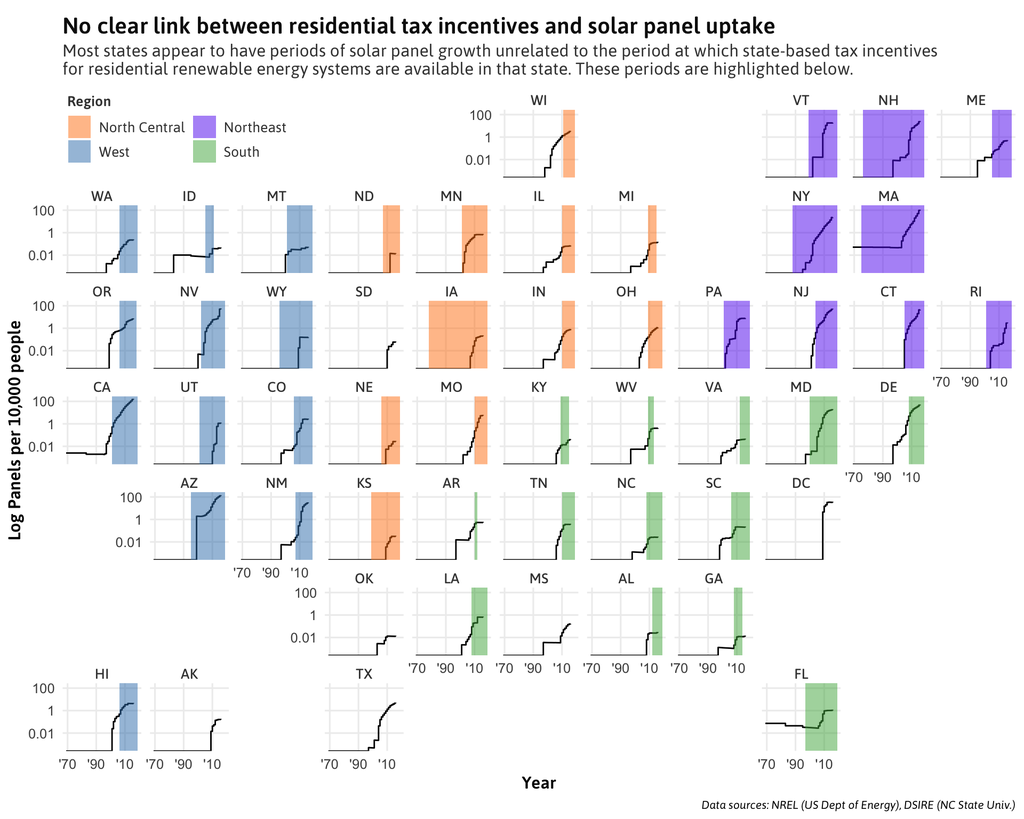

```r
# Plot of solar panel installation growth vs.
panels_by_pop %>%
  select(state, year, panels_per_10k) %>%
  mutate(region = state.region[match(state, state.abb)]) %>%
  ##### PLOT BEGINS
  ggplot() +
  geom_step(aes(x = year, y = panels_per_10k)) +
  geom_rect(data = policy %>%
              filter(sector == "Residential") %>%
              filter(!program_type %in% c("Corporate Tax Credit")) %>%
              select(state, start_date, end_date) %>%
              mutate(state = state.abb[match(state, state.name)]) %>%
              filter(!is.na(state)) %>%
              mutate(region = state.region[match(state, state.abb)]) %>%
              mutate(region = factor(region,
                       levels = c("North Central", "West", "Northeast", "South"))) %>%
              mutate(start_year = year(start_date),
                     end_year = ifelse(end_date > now(), NA, year(end_date))) %>%
              select(state, start_year, end_year, region) %>%
              group_by(state) %>%
              mutate(start_year = min(start_year),
                     end_year = max(end_year)) %>%
              mutate(end_year = ifelse(is.na(end_year), 2019, end_year)) %>%
              unique(),
            aes(xmin = start_year, xmax = end_year, ymin = 0, ymax = Inf,
                fill = region),
            alpha = 0.5) +
  facet_geo(~ state) +
  scale_y_log10(breaks = c(0.01, 1, 100),
                labels = c(0.01, 1, 100)) +
  scale_x_continuous(breaks = c(1970, 1990, 2010),
                     labels = c("'70", "'90", "'10")) +
  scale_fill_manual(name = "Region",
                    values = c('#FF810F','#377eb8', '#5D2BF0', '#4daf4a'),
                    guide = guide_legend(nrow = 2,
                                         title.position = "top",
                                         title.hjust = 0)) +
  labs(title = "No clear link between residential tax incentives and solar panel uptake",
       subtitle = "Most states appear to have periods of solar panel growth unrelated to the period at which state-based tax incentives \nfor residential renewable energy systems are available in that state. These periods are highlighted below.",
       x = "Year",
       y = "Log Panels per 10,000 people",
       caption = "Data sources: NREL (US Dept of Energy), DSIRE (NC State Univ.)") +
  theme_custom() +
  theme(strip.text = element_text(margin = margin(2, 0, 2, 0)),
        legend.direction = "horizontal",
        legend.position = c(0.12, 0.97))
```

```r
ggsave(here('output', 'panels-vs-policy.png'), width = 10, height = 8)
```

It appears that the periods where state-based financial incentives were available do not meaningfully coincide with periods of rapid solar panel installation growth. We are, however, painting with a very broad brush - the periods we’ve been looking at have been for all types of state incentives, be they property tax exemptions, tax credits, low-interest financing plans, etc. We’ll need a bit more contextual research to be able to meaningfully distinguish between them.

Meanwhile, installing a solar panel system may or may not be environmentally-motivated, but we can safely say it is a decision with a large financial component. Buyers put up with a high fixed cost upfront in order to enjoy long-term savings in the future, so the cheaper the cost of installation, the more likely installing solar panels will make financial sense. That suggests we should look at other factors impacting the cost of installing solar panels. We can start with the most obvious one - the cost of the panels themselves.

# How have solar panel costs changed?

As with any technology, we can generally expect efficiency and capacity to rise over time. Since solar panels have at least grown in their literal efficiency (i.e. amount of energy generated from the same amount of sunlight), it makes more sense to look at how much it costs to generate a single watt of electricity and how that’s changed over time.

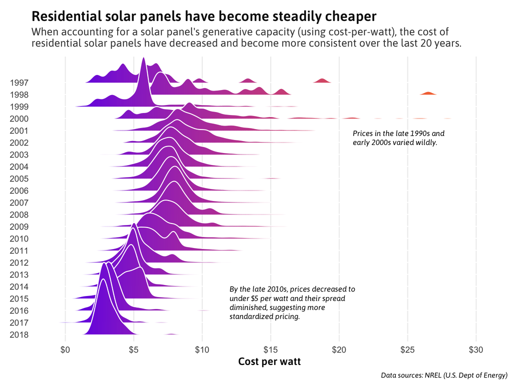

```r
panels %>%
  filter(install_type == "residential") %>%
  filter(year_installed >= 1997) %>%
  mutate(year_installed = factor(year_installed)) %>%
  ##### PLOT BEGINS
  ggplot(aes(x = cost_per_watt, y = fct_rev(year_installed))) +
  geom_density_ridges_gradient(aes(fill = ..x..),
                      color = "#FFFFFF",
                      na.rm = TRUE,
                      show.legend = FALSE,
                      scale = 5) +
  scale_x_continuous(breaks = seq(0, 30, 5),
                     labels = c("$0", "$5", "$10", "$15", "$20", "$25", "$30")) +
  scale_fill_gradient(low = "#5D2BF0", high = "#FF810F",
                      name = "Cost per watt",
                      breaks = seq(0, 30, 10),
                      labels = c("$0", "$10", "$20", "$30")) +
  labs(title = "Residential solar panels have become steadily cheaper",
       subtitle = "When accounting for a solar panel's generative capacity (using cost-per-watt), the cost of \nresidential solar panels have decreased and become more consistent over the last 20 years.",
       x = "Cost per watt",
       caption = "Data sources: NREL (U.S. Dept of Energy)") +
  annotate("text",
           x = 21, y = 18,
           label = "Prices in the late 1990s and \nearly 2000s varied wildly.",
           size = 3,
           lineheight = 1,
           hjust = 0, vjust = 1,
           family = "Asap",
           fontface = "italic",
           color = "#000000") +
  annotate("text",
           x = 12, y = 5,
           label = "By the late 2010s, prices decreased to \nunder $5 per watt and their spread \ndiminished, suggesting more \nstandardized pricing.",
           size = 3,
           lineheight = 1,
           hjust = 0, vjust = 1,
           family = "Asap",
           fontface = "italic",
           color = "#000000") +
  theme_custom() +
  theme(panel.grid.major.y = element_blank(),
        axis.text.y = element_text(margin = margin(0, 0, 0, 5)),
        axis.title.y = element_blank())
```

```r
ggsave(here('output', 'panel-cpw-by-year.png'), width = 8, height = 6)
```

While panels have gotten cheaper overall, what does this change look like for specific states? In particular, how has cost-per-watt changed for the three Northeast states we identified above - Massachussetts, New York, and New Jersey - that generated disproportionately high levels of solar energy relative to the solar irradiance they received?

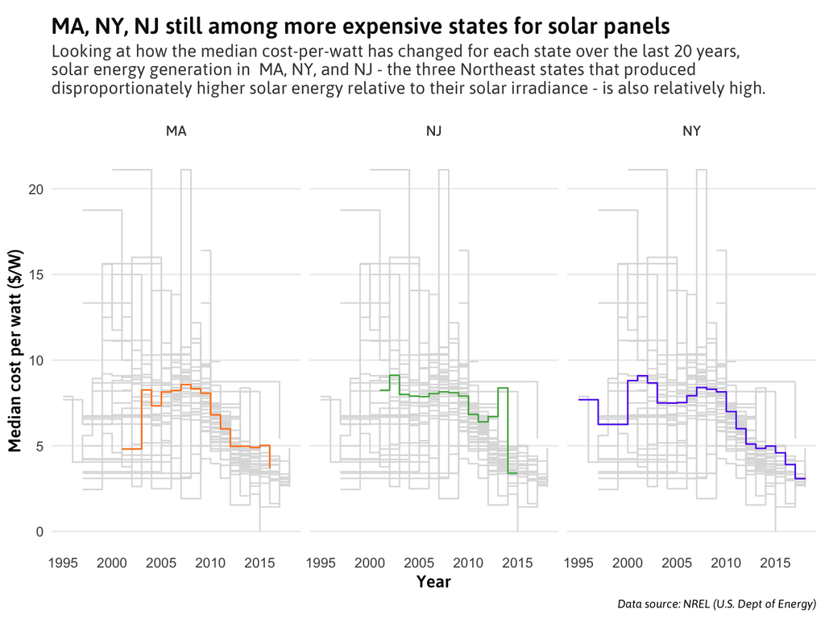

```r
panels %>%
  filter(install_type == "residential") %>%
  filter(year_installed >= 1990) %>%
  group_by(state, year_installed) %>%
  summarize(med_cpw = median(cost_per_watt, na.rm = TRUE)) %>%
  ##### PLOT BEGINS
  ggplot(aes(x = year_installed, y = med_cpw)) +
  geom_step(aes(color = state),
            na.rm = T,
            show.legend = FALSE) +
  gghighlight(state %in% c("NY", "MA", "NJ"),
              unhighlighted_colour = "#DDDDDD",
              use_group_by = F,
              use_direct_label = F) +
  facet_wrap(~ state) +
  scale_color_manual(values = c("#FF810F", "#4daf4a", "#5D2BF0")) +
  labs(title = "MA, NY, NJ still among more expensive states for solar panels",
       subtitle = "Looking at how the median cost-per-watt has changed for each state over the last 20 years, \nsolar energy generation in  MA, NY, and NJ - the three Northeast states that produced \ndisproportionately higher solar energy relative to their solar irradiance - is also relatively high.",
       x = "Year",
       y = "Median cost per watt ($/W)",
       caption = "Data source: NREL (U.S. Dept of Energy)") +
  theme_custom() +
  theme(panel.grid.major.x = element_blank())
```

```r
ggsave(here('output', 'panel-cpw-nestates.png'), width = 8, height = 6)
```

Interestingly enough, when looking at the path of each state’s median cost-per-watt over the course of the past 20 years, MA, NY and NJ all have had median costs on the high end of each year’s distribution. This places a wrench in my original hypothesis. It seems like we might need different data - say, cost-per-watt relative to each state’s median income.

# Next steps

As an ongoing project, I’d next like to look at the following factors as possible correlates of solar panel installation rates:

- Cost of electricity in each state
- A deeper look into the types of state tax incentives enacted, i.e. whether it was a tax deduction, a tax credit, a tax exemption, a low-interest loan program, size of the state’s renewable portfolio standard, and so on.

# Resources

## Data Sources

- Solar Energy Generation: [State Energy Data Systems (SEDS), U.S. Energy Information Administration](https://www.eia.gov/state/seds/)
- Solar Irradiance: [National Renewable Energy Laboratory, U.S. Department of Energy](https://www.nrel.gov/gis/data-solar.html)
- Solar Panel Installations: [OpenPV Project, NREL, U.S. Department of Energy](https://openpv.nrel.gov/)
- Population estimates: [Surveillance, Epidemiology and End Results (SEER) Program, National Cancer Institute](https://seer.cancer.gov/popdata/download.html)
- State Policies: [Database of State Incentives for Renewables & Efficiency (DSIRE), North Carolina State University](http://www.dsireusa.org/resources/data-and-tools/)

## Other

- Fonts: Asap, via [Google Fonts](https://fonts.google.com/specimen/Asap)
- Code for map color scale adapted from [Timo Grossenbacher](https://timogrossenbacher.ch/2016/12/beautiful-thematic-maps-with-ggplot2-only/)